# Topic model

Kang

## 简介

主题分析可用于对文本进行主题解读和分类。在本研究中，我们有600多个回答，我把这些回答根据他们所属的主题进行划分。该主题分析属于非监督分类方法，也就是说主题的含义不是预先定义好的，而是根据回答本身的特征进行分类，然后我们再根据分类后各个主题的关键词等信息解读各主题含义。一个类比是，如果你对一个班级的学生分类，可能会根据性别将他们分成两个或多个组；但是如果是对一个性别相同的团体进行分类，就不会把TA们分成男女，而是根据其他特征（例如身高）来分类。非监督分类方法就相当于对给定的一个有各种特征（性别、身高等）的群体，机器先判断哪个特征最适合区分群体中的个体，然后根据目标特征进行分类。

## 方法描述

文本分析的基本流程为：

（1）先读取所有回答（我们称每个回答为"文档"）。

（2）将每个文档进行分词，简单说就是把句子分成一个个的词语或词组。

（3）去除停止词，所谓的停止词是一些没有重要意义的词汇，例如汉语中的"的"。

（4）统计词语的频率，同时也可以计算词语的重要性（TF-IDF方法）。你可以想象，一个词语如果在一个文档中出现次数越多，通常越重要；但是如果它在其他所有文档中都出现，那就不重要；只有在某个文档中出现次数多，且其他文档中少出现的词才得高分。

（5）用主题模型对各个回答文档进行归类，结果呈现为每个文档被划分到各个主题的概率，例如，如果我们希望所有文档被归入3个主题中，那么某个文档属于主题1、2、3的概率可能分别是0.8、0.1、0.1。

（6）看对吃鹿肉和打猎的看法的打分和各个主题是什么关系。期待结果：例如会不会某个主题的打分通常更低，或者换个角度，会不会某个打分的人群更经常抱持某个主题观点。

## 判断主题数量

运用主题模型，需要先定义主题数量。如果主题数量很少，例如极端情况下（理论上并不合理），我们将所有文档只归入1个主题中，那么所有文档属于该主题的概率就是100%，这种主题划分就没有意义了；再往前一步，如果分成2个主题，如果文档之间有很好的区分度，那没有问题，但是也可能出现大部分文档归入两个主题的概率都差不多是50%，区分度不够高；反之，如果我们将600个文档归入将近600个主题，那每个文档肯定会有所属概率更高的主题类别，但是主题太多，归类的意义也就小了。因此，在定义主题数量的时候，我们希望尽量少，但是又有足够的区分度。

此处我使用的方法是：给定一个范围的主题数量（从2到20），得出各种情况下，每个文档属于各个主题的概率；计算每个文档划入各个主题的概率的基尼系数，如果基尼系数越高，说明这些概率越离散，区分度越高，反之则说明区分度较差。例如，在主题数量为3的情况下，文档A属于3个主题的概率是0.8、0.1、0.1，则基尼系数为0.7，文档B的概率是0.5、0.3、0.2，则基尼系数为0.3，显然前者比后者区分度要高，因为它几乎是很确定地属于第一个文档。这样一来，我们就有主题数量从2到20情况下分类结果中各文档概率的基尼系数，将它们进行排序，从基尼系数高的主题数量中，选一个最小的主题数量即可。

首先看看不同主题数量下，各个文档分属于不同主题的概率。下图中格子颜色表示概率，红色为高概率，绿色为低概率。如果某个子图中，一列中有非常红的红色和大量非常绿的绿色，就表示区分度很好；反之区分度较差。可见图2、3、4都是比较混沌的颜色，格子糊成一片，各个文档属于不同主题的概率基本上都在50%上下，区分度很差；而从图5开始，有了比较清晰的鲜红色和鲜绿色。

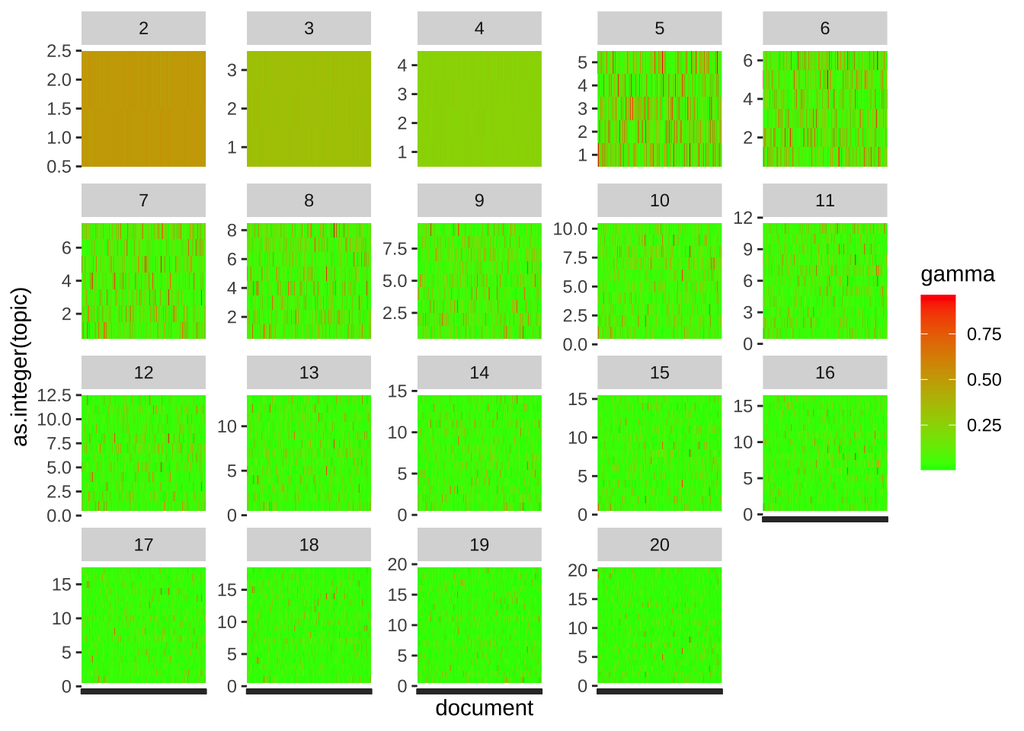

```r
id_topic_ls %>%
  bind_rows() %>%
  ggplot() +
  geom_tile(aes(document, as.integer(topic), fill = gamma)) +
  scale_fill_gradient(high = "red", low = "green") +
  theme(axis.text.x = element_blank()) +
  facet_wrap(.~ k, scales = "free_y")
```

[output not shown]

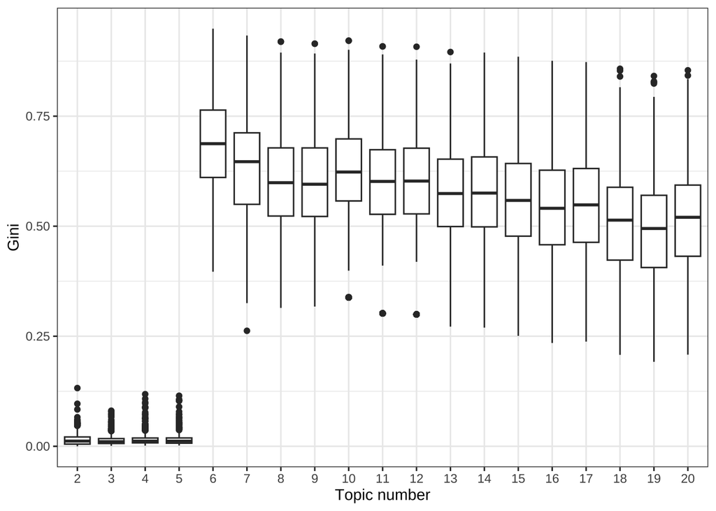

```r
id_topic_test %>%
  group_by(k, document) %>%
  summarise(gini = Gini(gamma)) %>%
  ungroup() %>%
  mutate(k = factor(k, levels = as.character(range_k))) %>%
  ggplot() +
  geom_boxplot(aes(k, gini)) +
  theme_bw() +
  labs(x = "Topic number", y = "Gini")
```

## 主题模型结果

下面先展示主题划分结果的区分度。然后查看主题划分结果中，各个主题的关键词，以及属于各个主题的若干文档原文。最后我们结合关键词和文档原文，解读各个主题的含义。

首先评估区分度。我将基尼系数划分为3个级别，每个级别下，各文档属于6个主题的概率如下图所示。可见基尼系数越高，鲜红色和鲜绿色就越多，也就是说区分度越高。符合预期。

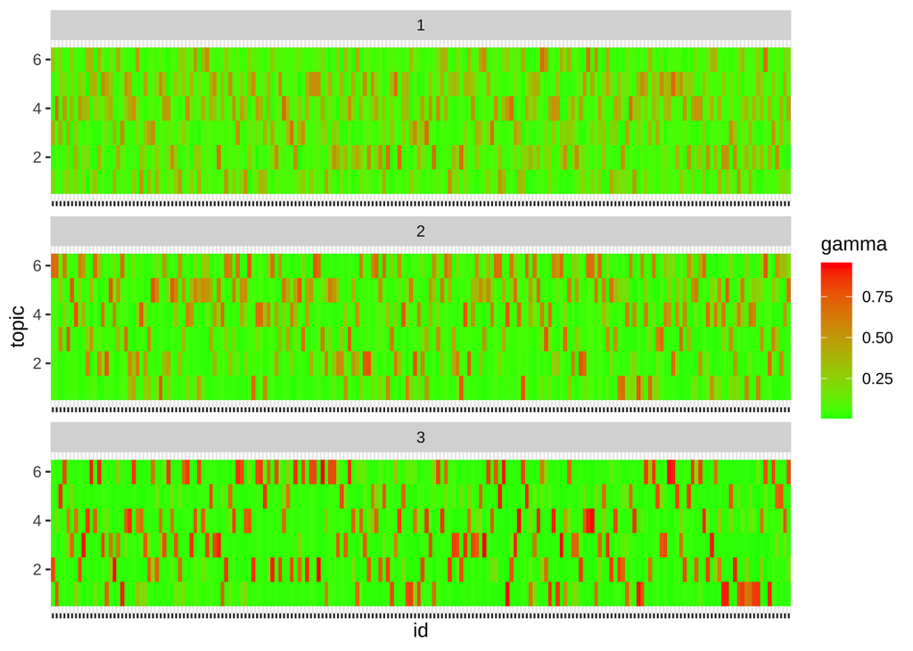

```r
id_topic %>%
  ggplot() +
  geom_tile(aes(id, topic, fill = gamma)) +
  facet_wrap(.~ gini_cls, scales = "free_x", ncol = 1) +
  theme(axis.text.x = element_blank()) +
  scale_fill_gradient(high = "red", low = "green")
```

6个主题的前15位关键词提取如下。需要说明一下这个结果之后可能会微调，因为我们的原始数据中有些小问题。

```r
library(knitr)
library(kableExtra)
tidy(lda, matrix = "beta") %>%
  group_by(topic) %>%
  slice_max(beta, n = 15) %>%
  mutate(term = reorder_within(term, beta, topic)) %>%
  summarise(term = list(term), .groups = "drop") %>%
  mutate(
    term = unlist(lapply(term, function(x) paste0(x, collapse = ", ")))
  ) %>%
  mutate(term = gsub("_", "", term), term = gsub("[0-9]", "", term)) %>%
  kable() %>%
  kable_styling()
```

| topic | term |
| --- | --- |
| 1 | 必要, 人間, できる, 的, 殺す, 数, 悪い, 野生, 処理, あまり, 思, 自然, 単に, ある程度, 食糧 \| |
| 2 | いい, 方, 良い, 人, 美味しい, 食肉, 食べる, シカ, 考え, そう, 鹿肉, 思, 聞, かわいそう, かも \| |
| 3 | 利用, 牛, 豚, よい, 処分, 動物, 鹿, 食肉, 殺, 害, 味, 鶏, いい, 食用, シカ \| |
| 4 | 活用, 増え, すぎ, 有効, ジビエ, 食肉, シカ, 鹿, 食用, 良い, しく, おい, 数, 資源, 好き \| |
| 5 | 駆除, 良い, 命, ただ, 無駄, ほうが, 食料, たく, いただく, 仕方, 美味, もの, 自然, 問題, 大切 \| |
| 6 | 食, べた, 肉, シカ, 食べる, 思, ジビエ, おいしい, いと, とも, もの, 気, 他の, 美味, あまり \| |

抽出各个主题下的若干文档原文。正如之前介绍的，某个回答文档通常并非完全属于某个主题，也就是说，就像我们日常说话一样，每个回答都包含了不止一个主题，它可能80%和主题1相关，15%和主题2相关，剩下5%在谈论主题3。所以在这里，我实际上是抽出各个主题下，和该主题最相关的几条回答文档。

```r
id_topic %>%
  group_by(topic) %>%
  arrange(topic, -gamma) %>%
  slice_head(n = 10) %>%
  ungroup() %>%
  # 漏洞：需要提前更改id的类型。
  left_join(mutate(survey, id = as.character(id)), by = "id") %>%
  select(id, topic, ven_reason_jp) %>%
  kable() %>%
  kable_styling()
```

| id | topic | ven_reason_jp |
| --- | --- | --- |
| 54 | 1 | できれば野生で暮らしてほしい。人間が自然を破壊することが原因では。人間都合の自然や社会が生態系を壊していて今後が心配です。 \| |
| 655 | 1 | 農地等にしかけられたワナに捕まった個体に限るなどの制限は必要 \| |
| 725 | 1 | Don’t have any information about it .so,I can’t say |
| 169 | 1 | あまり関係のないところに暮らしているので宝ヶ池などで見るくらいです \| |
| 729 | 1 | 一定数以上の増加であれば、自然界のバランスのためにも通常の事と考える \| |
| 759 | 1 | シカの数の調整は必要だが、積極的に捕まえるのは、微妙 \| |
| 584 | 1 | 生息数の管理のために必要だと思う（オオカミの変わりに） \| |
| 579 | 1 | 食糧危機にある中、必要なものに成ってくる。ただ、毛皮、角など、人間の道楽で、殺すことは許される事ではない。 \| |
| 756 | 1 | 処理する、しなりに関わらず費用及び手間等が関わる。ならば食を流通の中のテーブルに乗せ食を通して。京都で起きている被害状況を伝えることが（知って頂く）できるのではないかと思っています。 \| |
| 755 | 1 | 何回か頂き、調理、処理によっては、肩ロースなど最高の食材で、近くにジビエのレストランもある。悪い事ではないと思う。 \| |
| 355 | 2 | 食肉にすることが行き過ぎた目標になるのは良いと思えないが、生命が同じ地に生きるなら「いただく」というのも共存のための一つの選択かも知れない \| |
| 157 | 2 | 栄養が豊富で良いイメージ。買える場所が少ないからわからない。ネットで取り寄せている。気軽に身近に帰ると嬉しい。 \| |
| 741 | 2 | 生命を奪う代わりに、すべての部位を余すことなく料理し、生命に感謝を捧げる。 \| |
| 320 | 2 | メリット、デメリットそれぞれあるため。地方での先行事例で成功例をあまり聞かないため。 \| |
| 340 | 2 | スーパーで売っている肉類とシカが特に違うとは思わないから \| |
| 314 | 2 | 美味しいから。（しっかりと免許制度を徹底してほしい） \| |
| 29 | 2 | 寄生虫・ダニなどが心配される。病気を持っているかも \| |
| 593 | 2 | 鹿肉を食べる習慣がないので少し抵抗がある \| |
| 480 | 2 | 食肉として好む人もいそうなので \| |
| 712 | 2 | 生態系を守るため、増えすぎた野生動物等に限り良いのではないかと思います。特に鹿肉は、低脂肪で鉄分やビタミンが豊富にあると聞いたことがあるため \| |
| 586 | 3 | 今、話題になるジビエはただ捕獲してほかすのではどうかと思う。それもいいけど。犬、猫の餌に加工するとか動物園の肉食獣の餌にすればよいのでは。こういうことは余り公にならないようにすればよいのではある団体がうるさいし。 \| |
| 52 | 3 | 食肉が過熱し市街地に出てくるシカ以外も危険にさらされる可能性が高い。市街地であるという事をシカは理解できない \| |
| 713 | 3 | 没有这个习惯…像是要吃狗肉一样不舒服 \| |
| 133 | 3 | ジビエ料理といっても牛、ぶた、鶏と違って慣れていない、家畜として飼えない \| |
| 279 | 3 | 鹿鹿那么可爱怎么可以吃鹿鹿~ \| |
| 546 | 3 | 適切な生存個数が算定されているのであれば、その範囲での捕獲で対応すればよいと思う \| |
| 495 | 3 | 牛、豚、鳥、イノシシなどの動物と同様と思うから \| |
| 250 | 3 | 食用として飼われているのなら牛や豚などと変わりないと思う \| |
| 633 | 3 | シカは我々にとって犬、猫に近い存在だし \| |
| 482 | 3 | 鹿の食肉に対してのみ否定的な意見を持つことは、普段豚や牛などの肉から栄養を享受させていただいている身として命に差をつけていることになるため。 \| |
| 611 | 4 | 食材として活用することでプラス方向での問題解決が計れるのではないかと思う。鹿皮の活用も同時に考える。（子供の頃、鹿の皮のカバンや廃ブトンが身近にあった）やわらかくて良かった。 \| |
| 547 | 4 | テレビでよくジビエのおいしさを自慢する店があるが鹿を好きな子供足りの夢をぶち壊すことになる。 \| |
| 597 | 4 | ジビエを活用することは廃棄物を減らし、また地域活性化にもつなげられるから \| |
| 57 | 4 | シカが増えすぎていることからの森林、農地への影響があるなら、食肉として活用することは有効だと思う \| |
| 583 | 4 | 鹿が悪影響を与えているのなら、単純に数を減らせると思うから \| |
| 186 | 4 | 地元である北海道でもエゾシカを食用にしており、おいしくいただけているため。 \| |
| 708 | 4 | 増えすぎて数を減らすなら、食肉として活用するのも良いと思う \| |
| 137 | 4 | 色々の栄養素があるので工夫1つでおいしくなる。 \| |
| 653 | 4 | 活用し、資金が得られれば、活動の幅が広がると思う。 \| |
| 476 | 4 | 増えすぎて困っているのであれば食用として活用するのも選択肢になると思う \| |
| 537 | 5 | 駆除、安楽死させるのであれば、命を粗末にするより、頂くほうが良いのかもしれない。 \| |
| 556 | 5 | 安楽死させたくないが、もしするのであれば、ただ駆除で終わらせたくないと思う \| |
| 110 | 5 | 自然に戻せない場合は命を大切にいただくしかない \| |
| 317 | 5 | 過増殖による食肉化は、食文化の幅を広げるとともに、自然保護の推進にも役立つと思うから。 \| |
| 697 | 5 | 駆除されるならば感謝して頂くことが良いと思う \| |
| 675 | 5 | 駆除や安楽死に反対だから \| |
| 690 | 5 | 無駄にせず、命を循環させる \| |
| 272 | 5 | 駆除がもしされるのであれば、ありがたくいただくのが良い \| |
| 371 | 5 | 自然の命をちゃんといただく \| |
| 115 | 5 | 食料不足に対する策になる \| |
| 358 | 6 | 別に食べたくないから（山奥まで旅行してわざわざジビエを食べに行くことはあっても、日常生活で鹿肉を食べたくなる動機がないから。） \| |
| 685 | 6 | 出身が奈良県で何度かイノシシやシカのジビエを食べたことがある。ジビエを食べる風習のある地域があるため \| |
| 539 | 6 | 豚肉や牛肉で十分すぎる。飽食の時代にジビエまで食べたい又は食べようとは思わない。 \| |
| 138 | 6 | いずれ食糧難が来る。食べれるものを捨てることはない。日本人は食べ物を粗末にしすぎる。 \| |
| 378 | 6 | 実際にシカの肉を食べたことがないのでどちらとも言えません \| |
| 141 | 6 | 他の動物は食べたことがあるけれどシカは食べたことはないからわからない \| |
| 689 | 6 | 牛肉、豚肉、鶏肉も食べているから、私自身は鹿肉はあまり身近ではないためよくわからないから \| |
| 335 | 6 | 自然界の回りだから。食べたり、食べられたり。 \| |
| 296 | 6 | 自然のものを食べるのは当然（おいしい又は栄養があるなら） \| |
| 234 | 6 | 食べたことはないが食べたいとも思わないので \| |

**Just for fun：请你结合以上信息对各个主题进行含义概括，然后再找我要我的解读结果，我们可以核对一下我们的解读是否一致。当然，从工作效率角度说，也可以直接找我要结果用于写作。**

## 主题和打分

那么对食用鹿肉的态度、对狩猎的态度、谈论原因的主题之间是什么关系呢？

首先看看对食用鹿肉的态度和对狩猎态度的打分之间的关系。从下图可以看出，极度反感狩猎和极度喜欢狩猎的人都比较支持食用鹿肉，**为什么呢？需要从原始数据中找答案。**

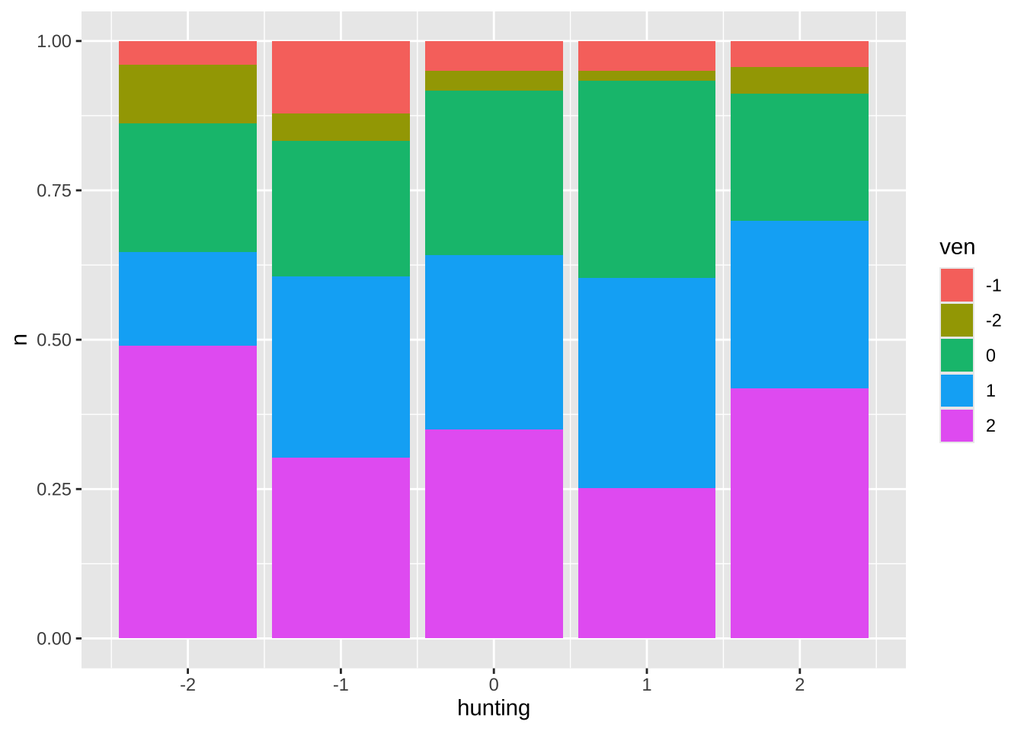

```r
survey %>%
  group_by(ven, hunting) %>%
  summarise(n = n(), .groups = "drop") %>%
  ggplot() +
  geom_col(aes(hunting, n, fill = ven), position = "fill")
```

那么对食用鹿肉的态度和谈论原因主题之间的关系呢？从下图可见，反对和中立的人更关注主题6，而支持的人更关注主题5，反对的人相比中立和支持的人，更关注主题2和3。

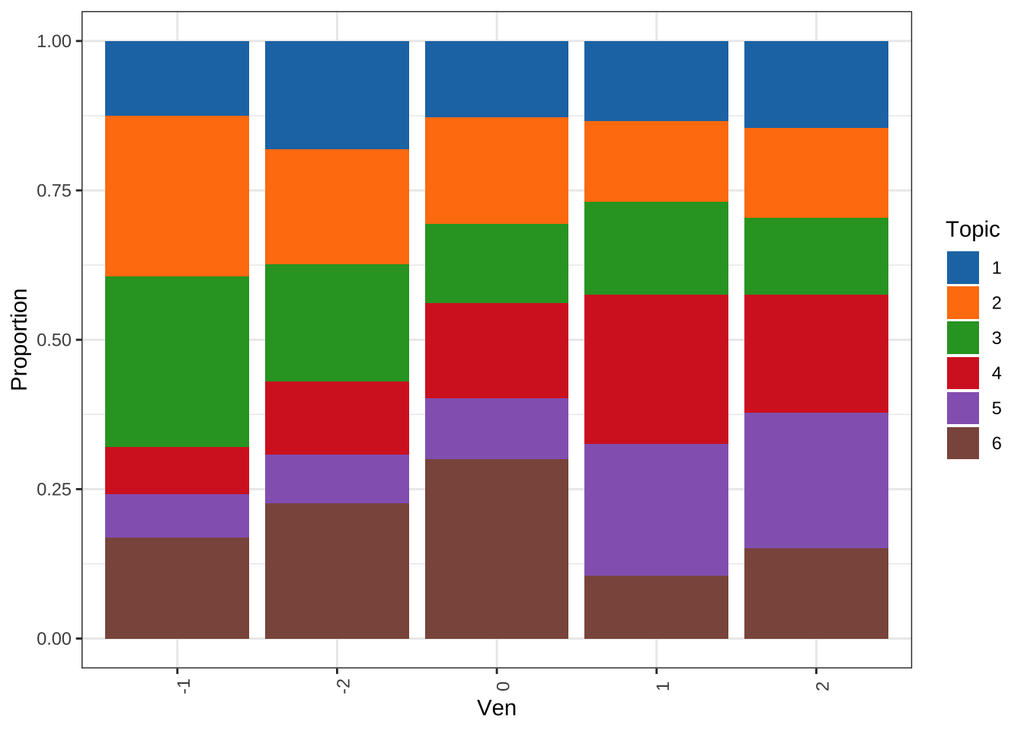

```r
id_topic %>%
  left_join(select(survey, id, ven), by = "id") %>%
  # 漏洞：应该早点把383号删除。
  filter(id != "383") %>%
  group_by(ven, topic) %>%
  summarise(gamma = sum(gamma), .groups = "drop") %>%
  ggplot() +
  geom_col(aes(ven, gamma, fill = as.character(topic)), position = "fill") +
  theme_bw() +
  scale_fill_d3() +
  labs(x = "Ven", y = "Proportion", fill = "Topic") +
  theme(axis.text.x = element_text(angle = 90))
```

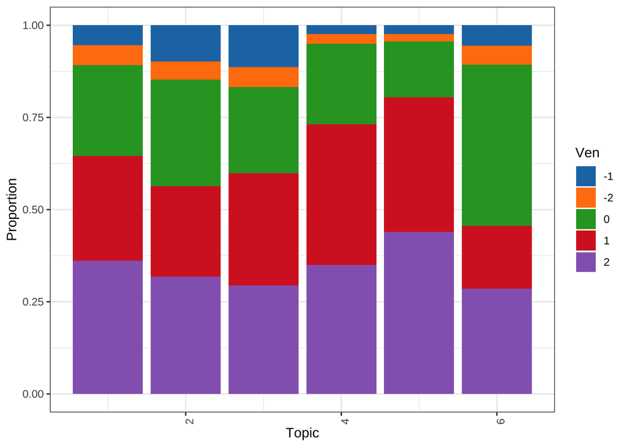

```r
id_topic %>%
  left_join(select(survey, id, ven), by = "id") %>%
  # 漏洞：应该早点把383号删除。
  filter(id != "383") %>%
  group_by(ven, topic) %>%
  summarise(gamma = sum(gamma), .groups = "drop") %>%
  ggplot() +
  geom_col(aes(topic, gamma, fill = as.character(ven)), position = "fill") +
  theme_bw() +
  scale_fill_d3() +
  labs(x = "Topic", y = "Proportion", fill = "Ven") +
  theme(axis.text.x = element_text(angle = 90))
```

那么对狩猎的态度和谈论原因主题之间的关系呢？同样可以从两个角度来看。注意这里有些人没有打分，所以原始数据还需要再调整。但是从下图可以看出，对狩猎态度与主题之间的关系比较弱（相比对食用态度和主题之间的关系而言）。当然这也合理，因为主题分析对象文档本身就是针对"对食用鹿肉态度"对扩展提问，而非针对"对狩猎态度"的扩展提问。

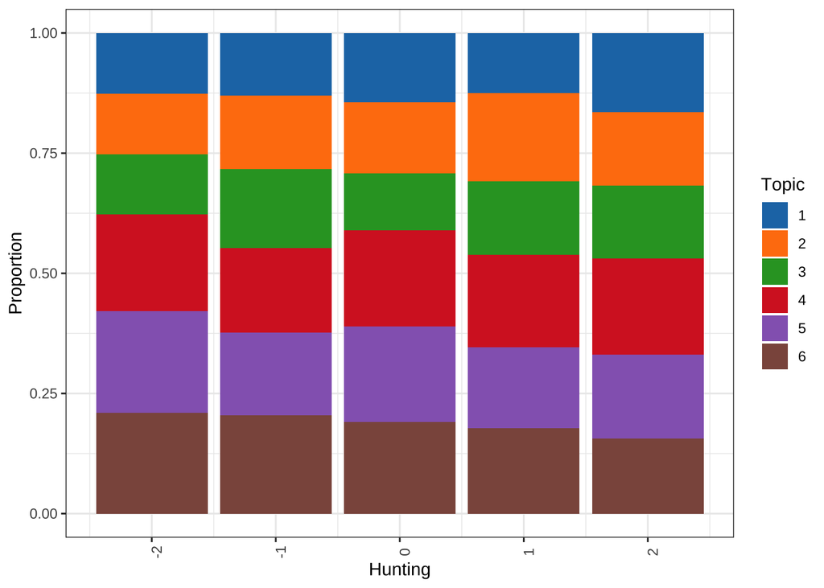

```r
# 对狩猎的态度和主题的关系。
id_topic %>%
  left_join(select(survey, id, hunting), by = "id") %>%
  # 漏洞：应该早点把383号删除。
  filter(id != "383") %>%
  group_by(hunting, topic) %>%
  summarise(gamma = sum(gamma), .groups = "drop") %>%
  ggplot() +
  geom_col(
    aes(hunting, gamma, fill = as.character(topic)), position = "fill"
  ) +
  theme_bw() +
  scale_fill_d3() +
  labs(x = "Hunting", y = "Proportion", fill = "Topic") +
  theme(axis.text.x = element_text(angle = 90))
```

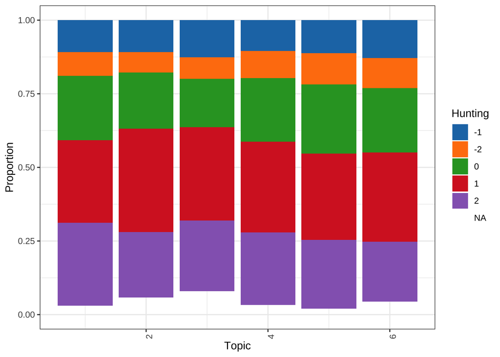

```r
id_topic %>%
  left_join(select(survey, id, hunting), by = "id") %>%
  # 漏洞：应该早点把383号删除。
  filter(id != "383") %>%
  group_by(hunting, topic) %>%
  summarise(gamma = sum(gamma), .groups = "drop") %>%
  ggplot() +
  geom_col(
    aes(topic, gamma, fill = as.character(hunting)), position = "fill"
  ) +
  theme_bw() +
  scale_fill_d3() +
  labs(x = "Topic", y = "Proportion", fill = "Hunting") +
  theme(axis.text.x = element_text(angle = 90))
```